# Justicia Ambiental y Fundamentos de SIG

SUS 2211 — Mapeando la (in)sustentabilidad

Felipe Jordán

2026-03-16

## Plan para hoy

### Primer bloque

- Ticket de entrada
- CT: Justicia Ambiental
- A+R: Justicia Ambiental en Chile

### Segundo bloque

- CT: Fundamentos de SIG
- A: Inducción a proyectos reproducibles en QGIS

# CT: Justicia Ambiental

## Lectura de la clase

> “Los patrones espaciales de distribución de las causas y consecuencias de la contaminación atmosférica están claramente controlados por la condición social de los habitantes de la ciudad.”

Romero, Fuentes y Smith (2010). *Ecología política de los riesgos naturales y de la contaminación ambiental en Santiago de Chile: necesidad de justicia ambiental.* Scripta Nova, Vol. XIV, nº 331.

## ¿Qué es la Justicia Ambiental?

> “Ningún grupo de personas debe cargar con una fracción desproporcionada de las consecuencias ambientales negativas que resultan de las operaciones o políticas de la industria, el gobierno o el comercio.”

Agencia de Protección Ambiental de EE.UU. (EPA)

## Dos tipos de justicia ambiental

**Justicia distributiva (JD)**

¿Quién carga con el daño?

- Distribución de contaminación
- Acceso a áreas verdes y amenidades
- Exposición a riesgos ambientales

**Justicia procedimental (JP)**

¿Quién tiene voz?

- Participación en decisiones
- Acceso a información y recursos legales
- Representación en espacios de poder

## No todos respiramos el mismo aire

- Las contaminación **no se distribuye al azar**
- Tiende a concentrarse en comunidades con **menos recursos** y **menor poder político**
- No es una coincidencia: es el resultado de decisiones e interacciones de mercado

[figure not shown]

Plantas industriales y vertederos rara vez se instalan en barrios de altos ingresos.

## Ejemplo: Carolina del Norte

[figure not shown]

Emisiones de grandes contaminadores y nivel de ingreso per cápita, Carolina del Norte (2010). Los puntos más grandes representan mayores emisiones. Fuente: EPA TRI.

## Nació en las calles, no en la academia

- El concepto surge de los **movimientos sociales** en los años 70 en EE.UU.
- **Warren County, NC (1982):** comunidad afroamericana bloqueó físicamente camiones que transportaban residuos tóxicos a su barrio
- La pregunta que hicieron esas comunidades fue simple: *¿por qué aquí?*
- Décadas después, la ciencia confirmó lo que esas comunidades ya sabían

## La evidencia es contundente

- Epidemiología, geografía, economía, urbanismo: **décadas de estudios consistentes**
- Grupos vulnerables — por ingreso, raza, o etnicidad — cargan con mayor exposición a:
  - Contaminación del aire y del agua
  - Proximidad a vertederos, plantas industriales, sitios de residuos peligrosos
- El patrón se observa en distintos países y escalas

## Ejemplo - Stgo: quién contamina y quién sufre

- Los sectores ricos (oriente) concentran los automóviles — la principal fuente de contaminación en Santiago
- Sin embargo, las peores concentraciones de material particulado se registran en los sectores pobres del poniente y las zonas bajas
- Se estima que **~2.500 personas mueren anualmente** por enfermedades asociadas a la contaminación del aire
- Los que más contaminan, menos sufren; los que menos contaminan, más sufren

Romero, Fuentes y Smith (2010).

# ¿Por qué emerge?

## Daño va donde resistencia es menor

- Industrias buscan **terrenos baratos** y **poca oposición**
- Barrios pobres y con menor organización ofrecen ambas cosas
- Decisiones de zonificación y regulación pueden reforzar esta lógica
- Carga ambiental se acumula donde hay menos poder

[figure not shown]

Vertederos e instalaciones de residuos peligrosos tienden a ubicarse en comunidades de bajos ingresos

## Los vulnerables también van al daño

[figure not shown]

Vivienda en zonas contaminadas: única opción para muchos.

[figure not shown]

Barrios limpios y con areas verdes tienden a ser acomodados.

El medioambiente limpio cuesta dinero. Quienes no pueden pagarlo terminan viviendo cerca de las fuentes de daño.

## Los ciclos se refuerzan

[figure not shown]

“Pirámide de la gentrificación ambiental”: la calidad ambiental, los precios del suelo y la demografía se influyen mutuamente en ciclos que pueden perpetuar la injusticia. Fuente: Banzhaf & McCormick (2012).

## JP alimenta la JD, y viceversa

- Quienes más sufren el daño son frecuentemente los que **menos participan** en las decisiones que lo generan
- Barreras: idioma, tiempo, recursos legales, acceso a información, representación política
- Sin voz en el proceso, los resultados distributivos raramente cambian
- **La injusticia procedimental es una causa, no solo una consecuencia**
- ¿Cómo es una consecuencia?

## JA para riesgos “naturales” - Un caso en Stgo

- Nuevos barrios ricos en **precordillera**
- + construcciones → + escorrentía → + inundaciones **aguas abajo**
- Mitigación se concentra en barrios ricos
- Pobres, aguas abajo, **desprotegidos**
- “Desastres naturales” también resultan de decisiones de política

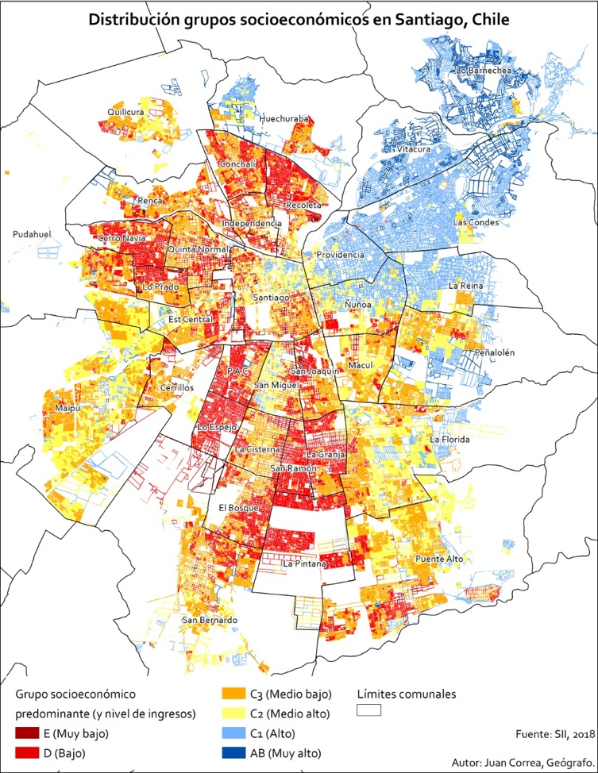

Stgo oriente concentra los sectores de mayores ingresos.

# Implicancias éticas

## ¿Y si es solo el mercado funcionando?

- Una objeción frecuente: *“si la gente elige vivir ahí porque es más barato, ¿cuál es el problema?”*
- Problema: esas “elecciones” se dan en un contexto de **opciones profundamente desiguales**
- Que la diferencia en exposición esté mediada por el ingreso **no la hace menos injusta**
- El origen del daño importa para juzgar su justicia — y para diseñar las respuestas

## Efectos intergeneracionales

- La exposición ambiental afecta la **salud, el desarrollo cognitivo y los ingresos futuros**
- Efectos documentados desde la exposición *in utero*
- Un niño que crece cerca de una fuente de contaminación llega en desventaja a la adultez
- La injusticia ambiental puede **reproducir y profundizar** la desigualdad socioeconómica

## ¿Por qué importa saber dónde está?

- No podemos corregir lo que no podemos ver ni medir
- **Mapear la injusticia ambiental** es el primer paso para intervenirla
- Las herramientas que estamos aprendiendo en este curso son exactamente las que se necesitan para hacer visibles las injusticias ambientales

# A+R: Herramientas para mapear la JA

## Herramientas para mapear la JA

En la clase anterior revisaste junto a tus compañeros una de tres herramientas de visualización de problemáticas de JA:

- CalEnvironScreen
- [Mapa de Conflictos Socioambientales de Chile](https://mapaconflictos.indh.cl/#/)
- Atlas de Risgos Climáticos

## Herramientas para mapear la JA

Y contestaron las siguientes preguntas guías:

- ¿Qué temáticas abordan la herramienta web en cuestión?
- ¿Qué rol juegan los mapas en ella?
- ¿Cómo puede la herramienta apoyar la gestión de los desafíos socioecológicos que aborda?
- ¿Puede la herramienta empoderar a grupos desaventajados?

## Caso de JA

Juntense en nuevas parejas que hayan visto la misma herramienta, escojan un caso de JA ilustrado por la herramienta, y respondan las siguientes perguntas:

- ¿Es un caso de justicia distributiva, procedimental o ambos?
- ¿Qué factores pueden explicar la injusticia en el caso elegido?
- ¿Qué consecuencias tiene para las comunidades afectadas?
- ¿Es efectiva la herramienta web para visualizar el caso de JA? ¿Cómo podría mejorarse?

## Discusión en plenario

1. Un grupo de cada herramienta presenta en 2 minutos su caso, utilizando la herramienta para ilustrarlo.
2. Discutimos en conjunto

# CT: Fundamentos de SIG

# Datum

## ¿Qué es un datum?

- La Tierra **no es una esfera perfecta**: es un geoide irregular
- Un **datum** es un modelo matemático que aproxima su superficie
- Permite describir la posición de cualquier punto con coordenadas
- Es la base de todo sistema de coordenadas geográficas

## Datum global y datum local

**Datum global**

- Se centra en el **centro de gravedad** de la Tierra
- El más usado: **WGS 1984**
- Estándar para GPS y cartografía global

**Datum local**

- Referenciado a un punto en la **superficie**
- Minimiza errores en una región específica
- Ejemplos: NAD27 (Norteamérica), ED1950 (Europa)

## Datum global y datum local

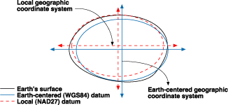

La Tierra como geoide. Ilustración de datum global (WGS84) y local (NAD27) superpuesto al geoide real. Fuente: ESRI.

# Proyecciones cartográficas

## ¿Qué es una proyección?

- Para hacer un mapa plano, debemos **“aplanar”** la superficie curva
- Una proyección es un **modelo matemático** que relaciona cada punto en el datum con un punto en un plano
- Gerardus Mercator (1512–1594) desarrolló la proyección más famosa del mundo

[figure not shown]

Gerardus Mercator.

## Familias de proyecciones

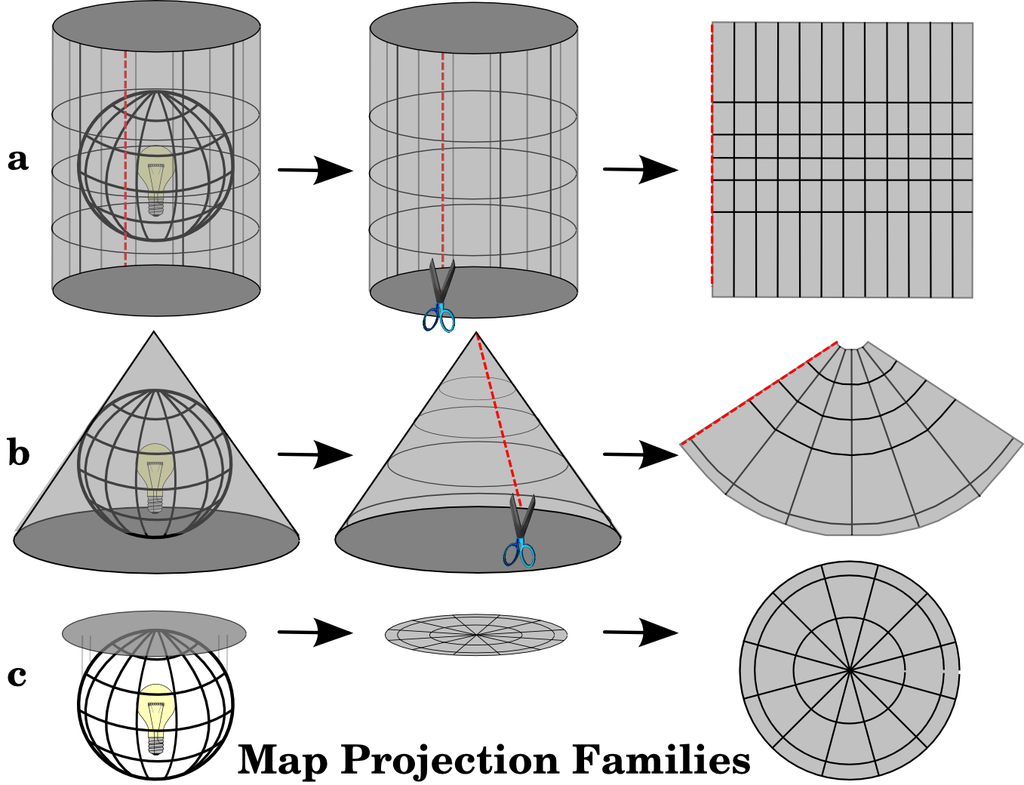

Tres familias: cilíndrica (a), cónica (b) y plana/acimutal (c). Fuente: ESRI

## Proyección Mercator: construcción

[figure not shown]

## Mercator distorsiona el área

- Paralelos y meridianos son **líneas rectas**
- Preserva **ángulos y formas** → útil para navegación
- **Distorsiona el área** hacia los polos
- Groenlandia aparece tan grande como África… ¡pero África es 14× mayor!

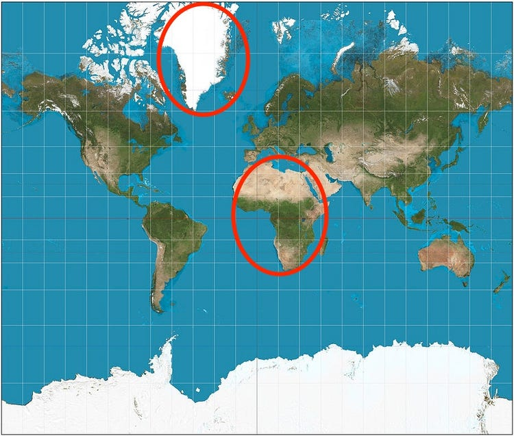

Groenlandia aparece tan grande como África en Mercator.

## ¿Qué tan grande es Groenlandia?

[figure not shown]

Groenlandia a escala real superpuesta sobre África. Fuente: Google Maps.

## Ninguna proyección es perfecta

- Toda proyección **distorsiona** al menos uno de:
  - **Área** (superficies)
  - **Forma** (ángulos)
  - **Distancia**
- Elección depende de **qué se quiere comunicar**

[figure not shown]

“Treating a human head the way a globe is treated by the Mercator projection.”

## La proyección depende del propósito

**Mercator**

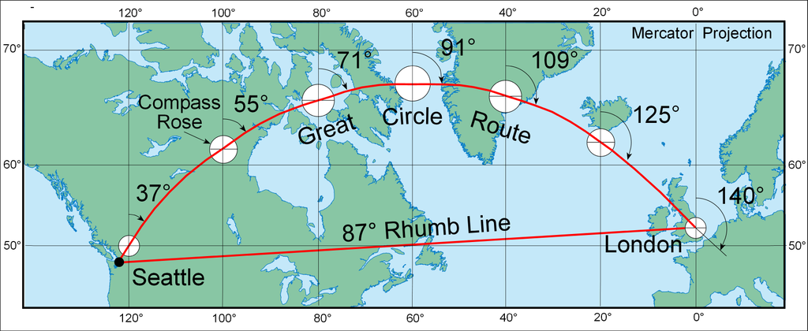

La línea recta Seattle–Londres **no** es la ruta más corta.

**Gnómica**

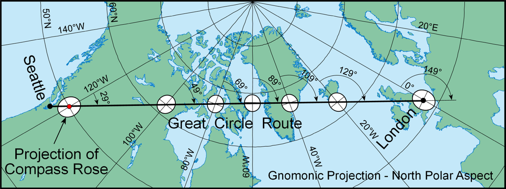

En proyección gnómica, la línea recta **sí** es la ruta más corta (pero distorsiona el ecuador).

## Proyecciones que preservan área

**Mollweide**

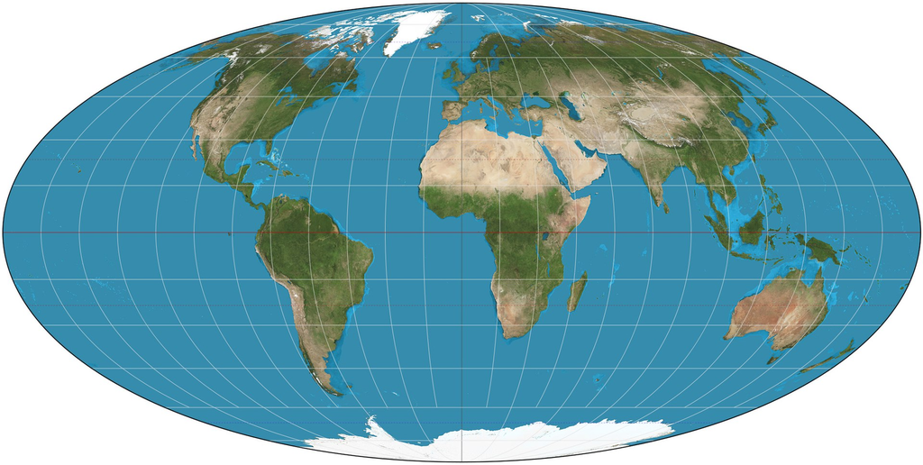

Preserva área correctamente, pero distorsiona formas.

**Lambert conformal conic**

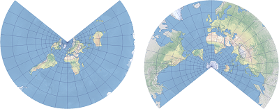

Preserva forma localmente, pero distorsiona áreas.

## Proyecciones de compromiso

**Platé Carrée**

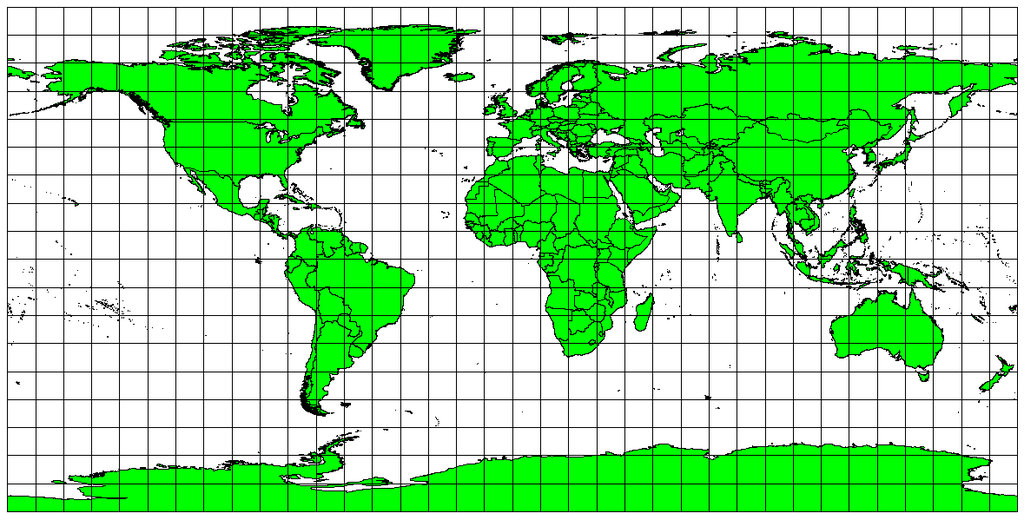

Distancia constante entre paralelos y meridianos.

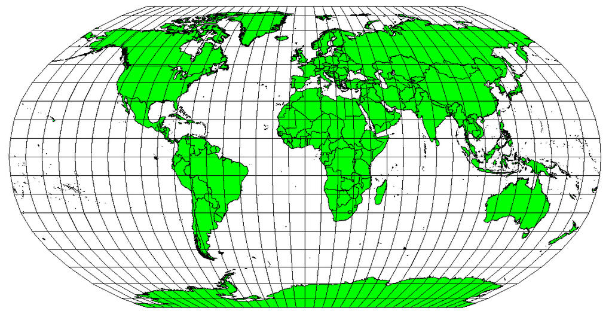

Equilibrio entre distorsiones de área, forma y distancia.

# Proyecciones locales y CRS

## Proyecciones locales

- A escala local, la Tierra se aproxima bien con un **plano tangente**
- Las proyecciones locales usan **metros** desde un punto de origen
- Un punto se expresa como **(x, y)**: horizontal, vertical
- Permiten calcular áreas y distancias con precisión

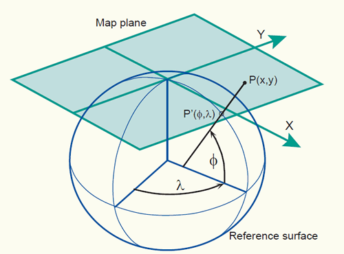

Plano tangente a la superficie del elipsoide.

## Sistema de referencia de coordenadas (CRS)

> ¿En qué lugar de la Tierra está un punto del mapa?

**CRS Geodético**

- 3D: latitud y longitud
- Requiere un **datum**
- Ej.: WGS 1984

**CRS Proyectado**

- 2D: coordenadas planas (x, y) en metros
- Requiere **datum + proyección**
- Ej.: UTM WGS84 Zona 19S

## ¿Cómo elegir el CRS?

- Para **mapas globales**: depende de lo que se quiere ilustrar (área, distancia, forma)
- Para **mapas locales**: elegir la proyección que minimice distorsiones en el área de interés
- Referencia estándar: base de datos **EPSG** (European Petroleum Survey Group)
- Para **Chile**: `EPSG:32718` (zona 18S) o `EPSG:32719` (zona 19S) — ambas UTM-WGS84

## Sistema UTM

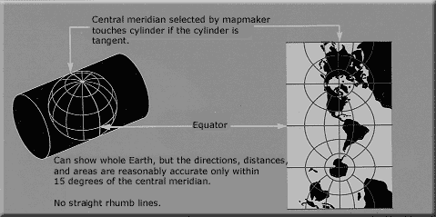

El sistema UTM divide la Tierra en 60 zonas cilíndricas de 6° de longitud.

## UTM en Chile

- Chile ocupa principalmente **dos zonas UTM**:
  - **Zona 18S** → sur de Chile (`EPSG:32718`)
  - **Zona 19S** → norte de Chile (`EPSG:32719`)
- La Región Metropolitana se encuentra en la **zona 19S**

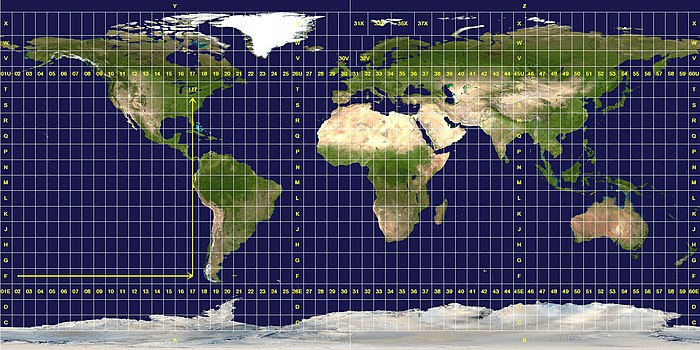

Grilla UTM mundial. Chile se extiende entre las zonas 18 y 19.

# Tipos de datos espaciales

## Vector y Raster

**Vector**

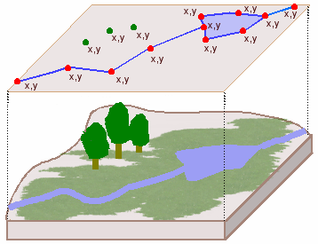

Puntos, líneas y polígonos. Representan objetos discretos.

**Raster**

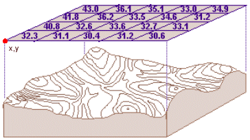

Grilla regular de celdas (píxeles). Representa fenómenos continuos.

# A: Inducción a proyectos reproducibles en QGIS

## ¿Por qué un proyecto reproducible?

- Tu análisis debe poder **ser retomado** por ti en otra sesión o en otro computador
- Debe poder **ser comprendido y replicado** por otra persona
- Las **rutas relativas** permiten mover toda la carpeta sin romper nada

**Regla de oro:** los datos originales nunca se modifican — se trabaja siempre con copias en `procesados/`

## Estructura de carpetas

[output not shown]

## Abrir el proyecto en QGIS

1. Descarga y descomprime el `.zip` Tarea 2 de los materiales de la clase
2. Abre la [página web del curso](https://felipejordanc.github.io/sus2211) y navega a la Tarea 2
3. Iniciaremos juntos esta primera guía